# Kruskal Wallis Tests for Account Dataset 2023 & 2024

Date: May 3, 2025

# Reading in the Dataset

We start off by reading the `.csv` file into a dataframe. This will allow us to perform the necessary operations needed to extract the data that we’re concerned about, as well as perform the statistical tests, which can give us more insights into the data.

**Note:** it is worth noting that we apply the bonferroni correction to all of our testing as well as set the signifigance level to 0.05.

```r
library(dplyr)
library(ggplot2)
library(rlang)
library(gridExtra)

# reading in the account data into data frames
account_2023 <- read.csv("C:/GitHub/BucksHackathon25/BucksBusinessObjectives/BucksDatasets/AccountLevel_2023.csv")
account_2024 <- read.csv("C:/GitHub/BucksHackathon25/BucksBusinessObjectives/BucksDatasets/AccountLevel_2024.csv")
```

## Kruskal Wallis Test on AvgSpend and FanSegment

Now that we’ve read the data into a data frame, we would like to perform a kruskal wallis test on the AvgSpend vs the FanSegment from both datasets. This will allow us compare a numerical variable against a categorical variable with multiple values.

- **Null Hyypothesis:** the distribution of average spending is the same across all segments
- **Alternative Hypothesis:** atleast one fan segment has a different distribution of average spending compared to others

```r
# performing a kruskal-wallis test
kruskal_one <- kruskal.test(AvgSpend ~ FanSegment, data=account_2023)
print(kruskal_one)
```

```
##
##  Kruskal-Wallis rank sum test
##
## data:  AvgSpend by FanSegment
## Kruskal-Wallis chi-squared = 105.36, df = 7, p-value < 2.2e-16
```

```r
# setting the data type as factor
account_2023$FanSegment <- as.factor(account_2023$FanSegment)


# performing the pair wise testing
rank_sum_one <- pairwise.wilcox.test(
    x = account_2023$AvgSpend,
    g = account_2023$FanSegment,
    p.adjust.method = "bonferroni")

# printg out the results
print(rank_sum_one)
```

```
##
##  Pairwise comparisons using Wilcoxon rank sum test with continuity correction
##
## data:  account_2023$AvgSpend and account_2023$FanSegment
##
##              A       B       C       D       E       F       G
## B            0.53387 -       -       -       -       -       -
## C            1.00000 1.00000 -       -       -       -       -
## D            1.00000 0.45105 1.00000 -       -       -       -
## E            1.00000 1.00000 1.00000 1.00000 -       -       -
## F            0.00065 0.00563 0.00641 0.00073 0.06595 -       -
## G            1.6e-13 4.9e-12 2.7e-11 8.7e-13 4.2e-09 0.14763 -
## Limited Data 0.15978 9.0e-05 0.32647 1.00000 0.14157 0.00019 8.7e-14
##
## P value adjustment method: bonferroni
```

As we can see, we now know that the FanSegment groups that show a statistically significant difference is as follows:

- F vs A, B, C and D
- G vs A, B, C, D and E

Now we perform the same kruskal-wallis testing on all features in 2024 dataset.

```r
# performing a kruskal-wallis test
kruskal_two <- kruskal.test(AvgSpend ~ FanSegment, data=account_2024)
print(kruskal_two)
```

```
##
##  Kruskal-Wallis rank sum test
##
## data:  AvgSpend by FanSegment
## Kruskal-Wallis chi-squared = 1091.8, df = 7, p-value < 2.2e-16
```

```r
# setting the data type as factor
account_2024$FanSegment <- as.factor(account_2024$FanSegment)

# performing the pair wise testing
rank_sum_two <- pairwise.wilcox.test(
    x = account_2024$AvgSpend,
    g = account_2024$FanSegment,
    p.adjust.method = "bonferroni")

# printg out the results
print(rank_sum_two)
```

```
##
##  Pairwise comparisons using Wilcoxon rank sum test with continuity correction
##
## data:  account_2024$AvgSpend and account_2024$FanSegment
##
##              A       B       C       D       E       F       G
## B            0.04041 -       -       -       -       -       -
## C            1.00000 1.00000 -       -       -       -       -
## D            1.00000 0.47552 1.00000 -       -       -       -
## E            9.8e-05 0.24900 0.01015 0.00112 -       -       -
## F            0.00023 1.00000 0.07975 0.00612 1.00000 -       -
## G            < 2e-16 < 2e-16 < 2e-16 < 2e-16 < 2e-16 < 2e-16 -
## Limited Data 1.00000 0.01308 1.00000 1.00000 6.2e-05 4.7e-05 < 2e-16
##
## P value adjustment method: bonferroni
```

As we can see, we now know that the FanSegment groups that show a statistically significant difference is as follows:

- E vs A, C and D
- F vs A and D
- G vs A, B, C, D, E and F

## Creating a Function for Performing Kruskal-Wallis Tests

Understanding the Kurskal-Wallis process, we decide to make a function that will make the process a whole lot easier

```r
# function for performing kruskal-wallis testing
run_kruskal_wallis <- function(dataset, response, group) {

    # performing the kruskal wallis test
    formula <- as.formula(paste(response, "~", group))
    kruskal_result <- kruskal.test(formula, data=dataset)
    print(kruskal_result)

    # accessing the p-value
    if(kruskal_result$p.value < 0.05) {
        cat("\n p-value is significant, running pairwise wilcox test \n")
        rank_sum_two <- pairwise.wilcox.test(
        x = dataset[[response]],
        g = dataset[[group]],
        p.adjust.method = "bonferroni")
        print(rank_sum_two)
    } else {
        cat("\n p-value is not significant \n")
    }

}

# testing out the function
run_kruskal_wallis(account_2024, 'AvgSpend', 'FanSegment')
```

```
##
##  Kruskal-Wallis rank sum test
##
## data:  AvgSpend by FanSegment
## Kruskal-Wallis chi-squared = 1091.8, df = 7, p-value < 2.2e-16
##
##
##  p-value is significant, running pairwise wilcox test
##
##  Pairwise comparisons using Wilcoxon rank sum test with continuity correction
##
## data:  dataset[[response]] and dataset[[group]]
##
##              A       B       C       D       E       F       G
## B            0.04041 -       -       -       -       -       -
## C            1.00000 1.00000 -       -       -       -       -
## D            1.00000 0.47552 1.00000 -       -       -       -
## E            9.8e-05 0.24900 0.01015 0.00112 -       -       -
## F            0.00023 1.00000 0.07975 0.00612 1.00000 -       -
## G            < 2e-16 < 2e-16 < 2e-16 < 2e-16 < 2e-16 < 2e-16 -
## Limited Data 1.00000 0.01308 1.00000 1.00000 6.2e-05 4.7e-05 < 2e-16
##
## P value adjustment method: bonferroni
```

## Kruskal Wallis Test on SocialMediaEngagement and BasketballPropensity

Next, we move on to performing the Kruskal-Wallis test on SocialMediaEngagement vs BasketballPropensity. As SocialMediaEngagement is a categorical feature with three distinct values of Low, Medium and High, we set the null and alternative hypothesis as follows:

- **Null Hypothesis:** the distribution of average propensity is the same across all engagement groups
- **Alternative Hypothesis:** atleast one engagement category has a different distribution of propensity compared to others

```r
# running the kruskal-wallis test for the 2023 dataset
run_kruskal_wallis(account_2023, 'BasketballPropensity', 'SocialMediaEngagement')
```

```
##
##  Kruskal-Wallis rank sum test
##
## data:  BasketballPropensity by SocialMediaEngagement
## Kruskal-Wallis chi-squared = 0.59535, df = 2, p-value = 0.7425
##
##
##  p-value is not significant
```

```r
# running the kruskal-wallis test for the 2024 dataset
run_kruskal_wallis(account_2024, 'BasketballPropensity', 'SocialMediaEngagement')
```

```
##
##  Kruskal-Wallis rank sum test
##
## data:  BasketballPropensity by SocialMediaEngagement
## Kruskal-Wallis chi-squared = 0.9171, df = 2, p-value = 0.6322
##
##
##  p-value is not significant
```

## Kruskal Wallis Test on FanSegment and DistanceToArena

Next, we move on to performing the Kruskal-Wallis test on FanSegment vs DistanceToArena. As FanSegment is a categorical feature with multiple distinct features, we set the null and alternative hypothesis as follows:

- **Null Hypothesis:** the distribution of distance to arena is the same across all fan segment groups
- **Alternative Hypothesis:** atleast one fan segment has a different distribution of distance compared to others

```r
# running the kruskal-wallis test for the 2023 dataset
run_kruskal_wallis(account_2023, 'DistanceToArena', 'FanSegment')
```

```
##
##  Kruskal-Wallis rank sum test
##
## data:  DistanceToArena by FanSegment
## Kruskal-Wallis chi-squared = 81.034, df = 7, p-value = 8.474e-15
##
##
##  p-value is significant, running pairwise wilcox test
##
##  Pairwise comparisons using Wilcoxon rank sum test with continuity correction
##
## data:  dataset[[response]] and dataset[[group]]
##
##              A       B       C       D       E       F       G
## B            0.03378 -       -       -       -       -       -
## C            8.4e-15 4.9e-07 -       -       -       -       -
## D            2.0e-06 0.08611 0.71070 -       -       -       -
## E            0.00873 1.00000 1.00000 1.00000 -       -       -
## F            1.00000 1.00000 1.00000 1.00000 1.00000 -       -
## G            1.00000 1.00000 0.13106 1.00000 1.00000 1.00000 -
## Limited Data 0.04495 1.00000 0.00025 0.80839 1.00000 1.00000 1.00000
##
## P value adjustment method: bonferroni
```

```r
# running the kruskal-wallis test for the 2024 dataset
run_kruskal_wallis(account_2024, 'DistanceToArena', 'FanSegment')
```

```
##
##  Kruskal-Wallis rank sum test
##
## data:  DistanceToArena by FanSegment
## Kruskal-Wallis chi-squared = 1298.7, df = 7, p-value < 2.2e-16
##
##
##  p-value is significant, running pairwise wilcox test
##
##  Pairwise comparisons using Wilcoxon rank sum test with continuity correction
##
## data:  dataset[[response]] and dataset[[group]]
##
##              A       B       C       D       E       F       G
## B            5.4e-05 -       -       -       -       -       -
## C            < 2e-16 3.3e-15 -       -       -       -       -
## D            < 2e-16 < 2e-16 1.00    -       -       -       -
## E            2.4e-16 3.0e-08 1.00    1.00    -       -       -
## F            0.13    1.00    3.4e-15 < 2e-16 5.3e-09 -       -
## G            < 2e-16 5.4e-12 0.76    1.00    1.00    2.4e-14 -
## Limited Data < 2e-16 < 2e-16 < 2e-16 < 2e-16 < 2e-16 < 2e-16 < 2e-16
##
## P value adjustment method: bonferroni
```

For the 2024 dataset, we interpret the results as follows:

- B vs A
- C vs A, B
- D vs A, B
- E vs A, B
- F vs C, D, E
- G vs A, B, F

## Kruskal Wallis Test on AvgSpend and SocialMediaEngagement

Next, we move on to performing the Kruskal-Wallis test on AvgSpend vs SocialMediaEngagement. As SocialMediaEngagement is a categorical feature with multiple distinct features, we set the null and alternative hypothesis as follows:

- **Null Hypothesis:** the distribution of average spending is the same across all engagement groups
- **Alternative Hypothesis:** atleast one engagement has a different distribution of average spending compared to others

```r
# running the kruskal-wallis test for the 2023 dataset
run_kruskal_wallis(account_2023, 'AvgSpend', 'SocialMediaEngagement')
```

```
##
##  Kruskal-Wallis rank sum test
##
## data:  AvgSpend by SocialMediaEngagement
## Kruskal-Wallis chi-squared = 1.1042, df = 2, p-value = 0.5757
##
##
##  p-value is not significant
```

```r
# running the kruskal-wallis test for the 2024 dataset
run_kruskal_wallis(account_2024, 'AvgSpend', 'SocialMediaEngagement')
```

```
##
##  Kruskal-Wallis rank sum test
##
## data:  AvgSpend by SocialMediaEngagement
## Kruskal-Wallis chi-squared = 1.8076, df = 2, p-value = 0.405
##
##
##  p-value is not significant
```

## Kruskal Wallis Test on FanSegment and GamesAttended

Next, we move on to performing the Kruskal-Wallis test on FanSegment vs GamesAttended. As FanSegment is a categorical feature with multiple distinct features, we set the null and alternative hypothesis as follows:

- **Null Hypothesis:** the distribution of games attended is the same across all fan segment groups
- **Alternative Hypothesis:** atleast one fan segment has a different distribution of games attended compared to others

```r
# running the kruskal-wallis test for the 2023 dataset
run_kruskal_wallis(account_2023, 'GamesAttended', 'FanSegment')
```

```
##
##  Kruskal-Wallis rank sum test
##
## data:  GamesAttended by FanSegment
## Kruskal-Wallis chi-squared = 223.83, df = 7, p-value < 2.2e-16
##
##
##  p-value is significant, running pairwise wilcox test
##
##  Pairwise comparisons using Wilcoxon rank sum test with continuity correction
##
## data:  dataset[[response]] and dataset[[group]]
##
##              A       B       C       D       E       F       G
## B            1.00000 -       -       -       -       -       -
## C            0.62637 0.23092 -       -       -       -       -
## D            4.8e-05 1.1e-05 1.00000 -       -       -       -
## E            1.00000 1.00000 1.00000 0.24185 -       -       -
## F            0.00034 0.00013 0.02736 0.20813 0.01448 -       -
## G            3.1e-09 1.0e-09 2.7e-06 2.2e-05 7.8e-06 1.00000 -
## Limited Data < 2e-16 2.3e-11 4.0e-11 < 2e-16 0.00887 2.1e-05 2.8e-09
##
## P value adjustment method: bonferroni
```

```r
# running the kruskal-wallis test for the 2024 dataset
run_kruskal_wallis(account_2024, 'GamesAttended', 'FanSegment')
```

```
##
##  Kruskal-Wallis rank sum test
##
## data:  GamesAttended by FanSegment
## Kruskal-Wallis chi-squared = 2036.5, df = 7, p-value < 2.2e-16
##
##
##  p-value is significant, running pairwise wilcox test
##
##  Pairwise comparisons using Wilcoxon rank sum test with continuity correction
##
## data:  dataset[[response]] and dataset[[group]]
##
##              A       B       C       D       E       F       G
## B            1.0000  -       -       -       -       -       -
## C            0.0020  0.0909  -       -       -       -       -
## D            2.7e-08 8.9e-05 1.0000  -       -       -       -
## E            3.7e-07 7.8e-05 1.0000  1.0000  -       -       -
## F            1.0000  1.0000  0.7201  0.0114  0.0027  -       -
## G            < 2e-16 < 2e-16 < 2e-16 < 2e-16 < 2e-16 < 2e-16 -
## Limited Data < 2e-16 < 2e-16 < 2e-16 < 2e-16 < 2e-16 < 2e-16 < 2e-16
##
## P value adjustment method: bonferroni
```

For the 2023 dataset, we interpret the results as follows:

- D vs A, B
- F vs A, B, C and E
- G vs A, B, C, D and E

For the 2024 dataset, we interpret the results as follows:

- C vs A
- D vs A, B
- E vs A, B
- F vs D, E
- G vs A, B, C, D, E and F

## Kruskal Wallis Test on SocialMediaEngagement and GamesAttended

Next, we move on to performing the Kruskal-Wallis test on GamesAttended vs SocialMediaEngagement. As SocialMediaEngagement is a categorical feature with multiple distinct features, we set the null and alternative hypothesis as follows:

- **Null Hypothesis:** the distribution of games attended is the same across all engagement groups
- **Alternative Hypothesis:** atleast one engagement group has a different distribution of games attended compared to others

```r
# running the kruskal-wallis test for the 2023 dataset
run_kruskal_wallis(account_2023, 'GamesAttended', 'SocialMediaEngagement')
```

```
##
##  Kruskal-Wallis rank sum test
##
## data:  GamesAttended by SocialMediaEngagement
## Kruskal-Wallis chi-squared = 3.7487, df = 2, p-value = 0.1535
##
##
##  p-value is not significant
```

```r
# running the kruskal-wallis test for the 2024 dataset
run_kruskal_wallis(account_2024, 'GamesAttended', 'SocialMediaEngagement')
```

```
##
##  Kruskal-Wallis rank sum test
##
## data:  GamesAttended by SocialMediaEngagement
## Kruskal-Wallis chi-squared = 0.14409, df = 2, p-value = 0.9305
##
##
##  p-value is not significant
```

## Creating a Function for Interactive Box Plots

Now, we would like to create a function for plotting out the box plots for features that are significant when it comes to post-hoc testing. We would like to visualize them into box plots to see how they compare.

```r
# declaring the library
library(ggplot2)

# defining function for plotting a box plot
plot_box_plot <- function(dataset, response, group, vector, title) {

    # converting group to symbol
    group_sym <- sym(group)

    # filtering out the data
    filtered_data <- dataset %>%
        filter(!!group_sym %in% vector)


    filtered_data[[group]] <- factor(
        filtered_data[[group]],
        levels = vector
    )

    ggplot(filtered_data, aes(x = .data[[group]], y = .data[[response]])) +
        geom_boxplot(fill = "skyblue") +
        labs(title = title, x = group, y = response) +
        theme_minimal()
}
```

## Box Plots for AvgSpend vs FanSegment

For the 2023 data set, we create the box plots that compare the following:

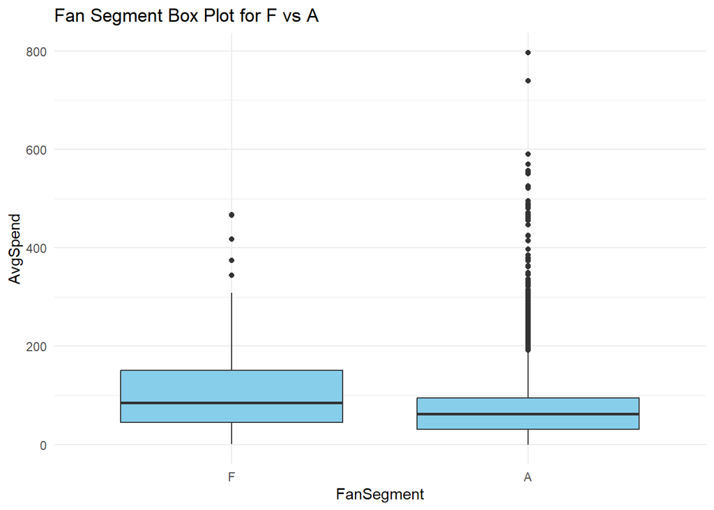

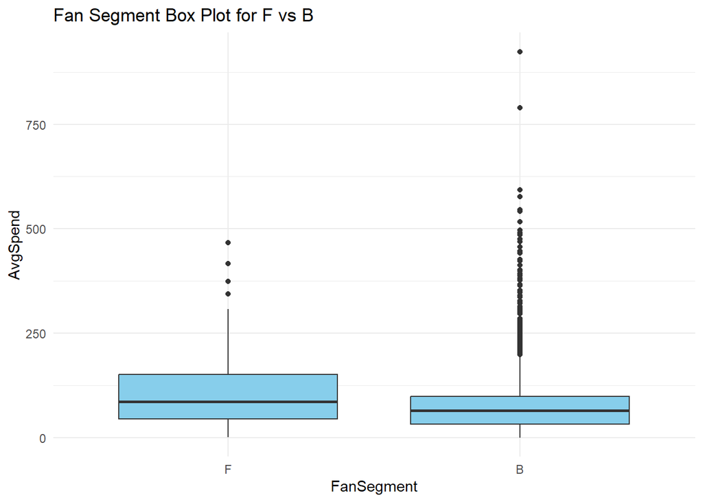

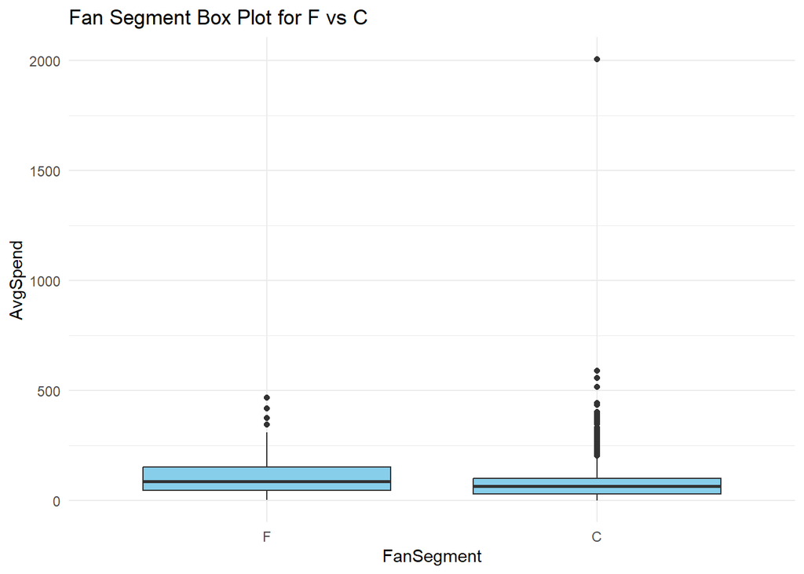

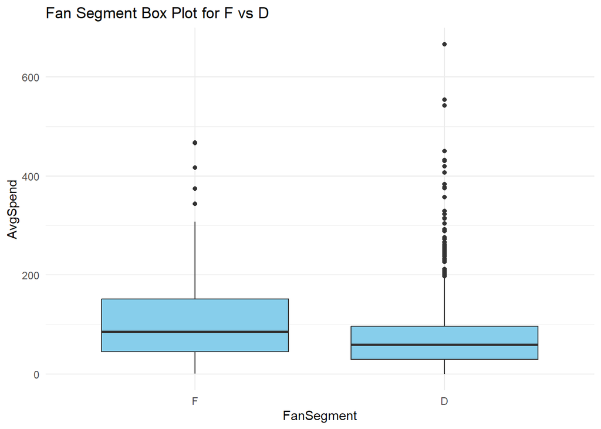

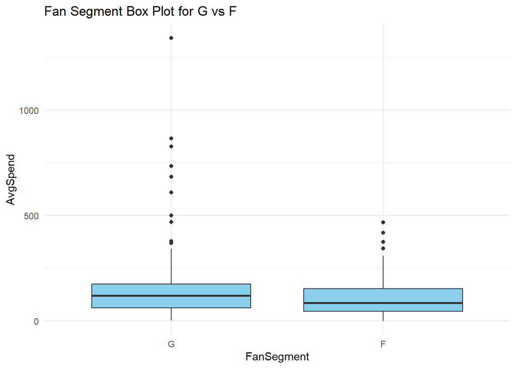

```r
# setting up a list of vectors
vector_list <- list(
  c("F", "A"),
  c("F", "B"),
  c("F", "C"),
  c("F", "D"),
  c("G", "F")
)

# for looping through the vectors
for(vec in vector_list) {
    title <- paste("Fan Segment Box Plot for", vec[1], "vs", vec[2])
    p <- plot_box_plot(account_2023, "AvgSpend", "FanSegment", vec, title)
    print(p)
}
```